# How Does a Bike-Share Navigate Speedy Success?

IronKing24

2023-11-13

```r
db <- try(dbConnect(SQLite(), dbname = file.path(params$path, "../data/db/Divvy.sqlite")))
```

# Ask

## Business task

Find the matching patterns between members and none members to influence the new marketing strategy that is aimed to increase members count.

# Prepare

## Data sources

The trips and stations data was located at [Divvy’s historical data](https://divvy-tripdata.s3.amazonaws.com/index.html) released under the [data license agreement](https://divvybikes.com/data-license-agreement).

# Process

**Data change log**

1. The `trips data files from the ye`ar 2013 up to the year 2019 where merged under a single file.
2. The columns of the station names where removed.
3. The column headers’ names were unified to (id, start_time, stop_time, from_station_id, to_station_id, user_type, gender, birth_year).
4. The genders where changed for 0 for null, 1 for male, and 2 for female.
5. The the customers value was changed to 0, the subscribers value was changed to 1, and the dependent value was changed to 2.
6. Removed trips with the same id.
7. Removed trips with negative duration.

# Analyze

```r
avg_duration <- db %>%
  tbl("trips") %>%
  filter(between(start_time, unixepoch(!!params$date[1]), unixepoch(!!params$date[2]))) %>%
  select(duration) %>%
  summarize(avg = round(mean(duration, na.rm = TRUE), 2)) %>%
  as_tibble() %>%
  seconds_to_period() %>%
  toString()
```

```r
max_duration <- db %>%
  tbl("trips") %>%
  filter(between(start_time, unixepoch(!!params$date[1]), unixepoch(!!params$date[2]))) %>%
  select(duration) %>%
  summarize(max = max(duration, na.rm = TRUE)) %>%
  as_tibble() %>%
  seconds_to_period() %>%
  toString()
```

```r
mode_duration <- db %>%
  tbl("trips") %>%
  filter(between(start_time, unixepoch(!!params$date[1]), unixepoch(!!params$date[2]))) %>%
  select(week_day) %>%
  as_tibble() %>%
  mutate(week_day = wday(week_day, label = TRUE, abbr = FALSE)) %>%
  group_by(week_day) %>%
  summarize(n = n()) %>%
  slice_max(n) %>%
  .$week_day %>%
  toString()
```

The mean ride duration is 16M 55.4400000000001S.

The maximum trip duration is 37d 13H 54M 2S.

The mode of the week day is Monday.

```r
db %>%
  tbl("trips") %>%
  filter(between(start_time, unixepoch(!!params$date[1]), unixepoch(!!params$date[2]))) %>%
  select(week_day, duration, user_type) %>%
  mutate(user_type = case_match(user_type , 0 ~ "Customer", 1 ~ 'Subscriber', 2 ~ "Dependent")) %>%
  as_tibble() %>%
  mutate(week_day =  fct_relevel(wday(week_day, label = TRUE, abbr = FALSE))) %>%
  group_by(week_day, user_type) %>%
  summarize(.groups="keep", "Number of trips" =  n(), "Average trip duration" = mean(duration, na.rm = TRUE)) %>%
  rename("Day of the week" = week_day, "User type" = user_type) %>%
  datatable(caption = "User type and week day pivot table", filter = 'top', options = list(pageLength = 21))
```

|  | Day of the week | User type | Number of trips | Average trip duration |
| --- | --- | --- | --- | --- |
| 1 | Sunday | Customer | 3444 | 4125.853368176539 |
| 2 | Sunday | Subscriber | 12567 | 723.7152064931964 |
| 3 | Monday | Customer | 2100 | 2628.570952380952 |
| 4 | Monday | Subscriber | 24302 | 662.2073903382437 |
| 5 | Tuesday | Customer | 1339 | 5264.851381628081 |
| 6 | Tuesday | Subscriber | 21417 | 678.044217210627 |
| 7 | Wednesday | Customer | 1778 | 3231.016872890889 |
| 8 | Wednesday | Subscriber | 18328 | 665.7733522479267 |
| 9 | Thursday | Customer | 2713 | 3370.332473276815 |
| 10 | Thursday | Subscriber | 22798 | 681.9735941749276 |

[output cut: 4 more lines]

# Share

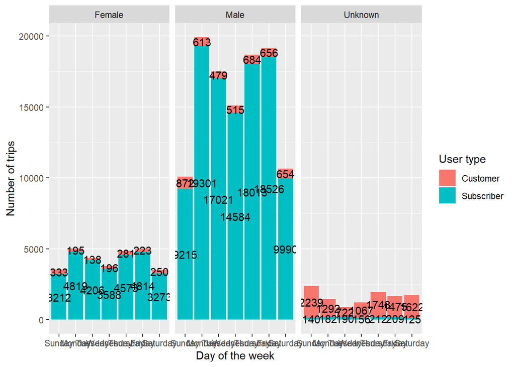

```r
# bar blot of week days
ggplot(
  db %>%
    tbl("trips") %>%
    filter(between(start_time, unixepoch(!!params$date[1]), unixepoch(!!params$date[2]))) %>%
    select(week_day, user_type, gender) %>%
    as_tibble() %>%
    mutate(week_day = fct_relevel(wday(week_day, label = TRUE, abbr = FALSE)),
           user_type = case_match(user_type , 0 ~ "Customer", 1 ~ 'Subscriber', 2 ~ "Dependent"),
           gender = case_match(gender , 0 ~ "Unknown", 1 ~ 'Male', 2 ~ "Female", 9 ~ "Not applicable")) %>%
    group_by(gender, week_day, user_type) %>%
    summarise(n = n(), .groups="keep"),
  aes(x = week_day, y = n ,fill = user_type)) +
  geom_bar(stat = 'identity', position="stack") +
  facet_wrap(~gender) +
  labs(fill = 'User type') +
  geom_text(aes(label = n), position = position_stack(vjust = 0.5)) +
  xlab("Day of the week") +
  ylab("Number of trips")
```

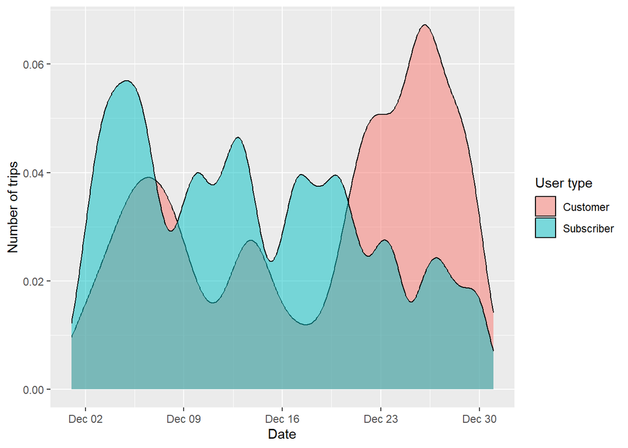

```r
#time series for ride count
ggplot(
  db %>%
    tbl("trips") %>%
    filter(between(start_time, unixepoch(!!params$date[1]), unixepoch(!!params$date[2]))) %>%
    select(user_type, start_time) %>%
    as_tibble() %>%
    mutate(
      start_time = date(as.POSIXct(start_time, origin = "1970-1-1")),
      user_type = case_match(user_type , 0 ~ "Customer", 1 ~ 'Subscriber', 2 ~ "Dependent")),
  aes(x = start_time, group = user_type, fill = user_type)) +
  geom_density(alpha = 0.5) +
  labs(fill = 'User type') +
  xlab("Date") +
  ylab("Number of trips") +
  scale_y_continuous()
```

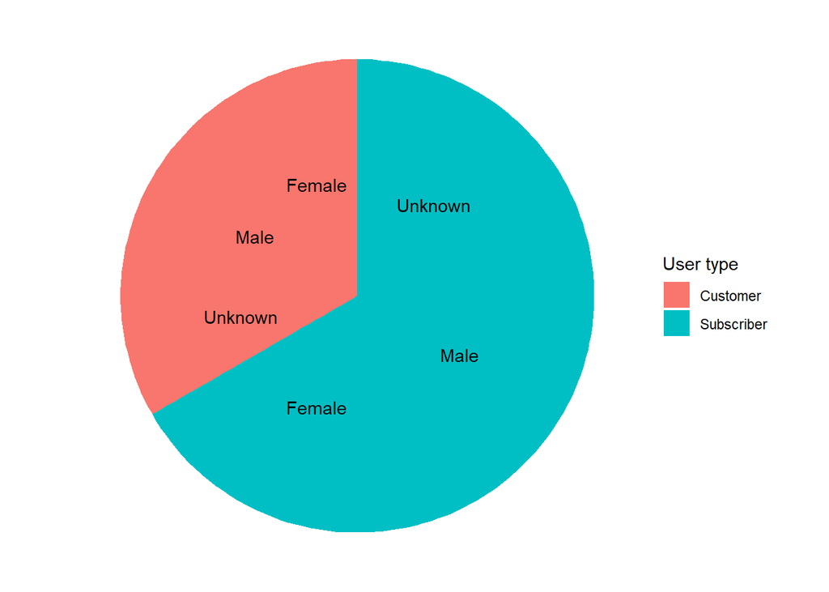

```r
#pie chart for users gender groups
ggplot(
  db %>%
    tbl("trips") %>%
    filter(between(start_time, unixepoch(!!params$date[1]), unixepoch(!!params$date[2]))) %>%
    select(user_type, gender) %>%
    group_by(user_type, gender) %>%
    summarise(Number = n(), .groups = "keep") %>%
    as_tibble() %>%
    mutate(
      user_type = case_match(user_type , 0 ~ "Customer", 1 ~ 'Subscriber', 2 ~ "Dependent"),
      gender = case_match(gender , 0 ~ "Unknown", 1 ~ 'Male', 2 ~ "Female", 9 ~ "Not applicable")),
  aes(x = "", y = user_type, fill = user_type)) +
  geom_bar(stat = "identity", width = 1) +
  coord_polar(theta = "y", start = 0) +
  theme_void() +
  geom_text(aes(x = "", y = user_type,label = gender), position = position_stack(vjust = 0.5)) +
  labs(fill = 'User type')
```

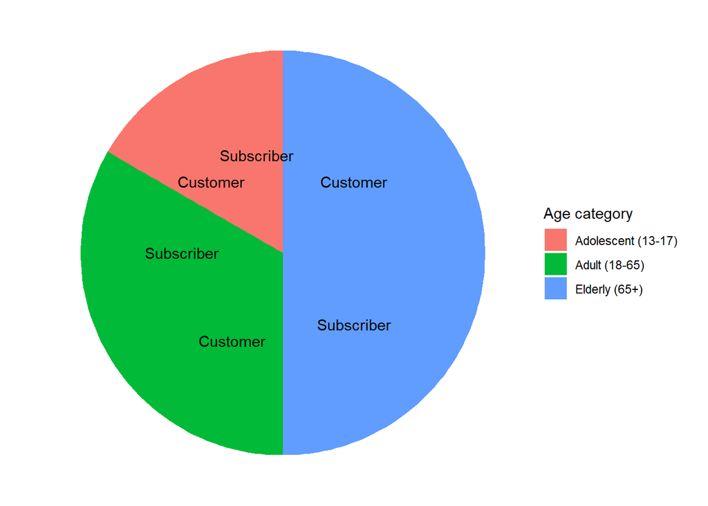

```r
#pie chart for age groups
ggplot(
  db %>%
    tbl("trips") %>%
    filter(between(start_time, unixepoch(!!params$date[1]), unixepoch(!!params$date[2])) & birth_year > 0) %>%
    select(birth_year, start_time, user_type) %>%
    as_tibble() %>%
    mutate(
      user_type = case_match(user_type , 0 ~ "Customer", 1 ~ 'Subscriber', 2 ~ "Dependent"),
      age = year(as.POSIXct(start_time, origin = "1970-1-1")) - birth_year,
      cat = case_when(
        age < 1 ~ "Infant (less than 1)",
        age >= 1 & age <= 12 ~ "Child (1-12)",
        age >= 13 & age <= 17 ~ "Adolescent (13-17)",
        age >= 18 & age <= 65 ~ "Adult (18-65)",
        age > 65 ~ "Elderly (65+)")) %>%
    group_by(user_type, cat) %>%
    summarise(Number = n(), .groups = "keep"),
  aes(x = "", y = cat, fill = cat)) +
  geom_bar(stat = "identity", width = 1) +
  coord_polar(theta = "y", start = 0) +
  theme_void() +
  geom_text(aes(x = "", y = cat, label = user_type), position = position_stack(vjust = 0.5)) +
  labs(fill = 'Age category')
```

```r
#plot map
col <- colorNumeric(palette = "YlOrRd", domain = NULL)

bind_rows(
  db %>%
    tbl("trips") %>%
    filter(between(start_time, unixepoch(!!params$date[1]), unixepoch(!!params$date[2]))) %>%
    select(from_station_id, start_time) %>%
    rename(id = from_station_id, time = start_time) %>%
    as_tibble(),
  db %>%
    tbl("trips") %>%
    filter(between(end_time, unixepoch(!!params$date[1]), unixepoch(!!params$date[2]))) %>%
    select(to_station_id, end_time) %>%
    rename(id = to_station_id, time = end_time) %>%
    as_tibble()
    ) %>%
  group_by(id) %>%
  summarise(freq = n(), .groups = "keep") %>%
  inner_join(
    db %>%
      tbl("stations") %>%
      select(id, name, status, longitude, latitude) %>%
      as_tibble(),
    by = "id"
    ) %>%
  as_tibble() %>%
  st_as_sf(coords = c("longitude", "latitude"), remove = TRUE) %>%
  leaflet() %>%
  addTiles() %>%
  addCircleMarkers(
    label = ~name,
    color = ~col(freq),
    stroke = ~ifelse(status,TRUE, FALSE),
    fillOpacity = 0.8) %>%
  addLegend("bottomright",
            pal = col,
            values = ~freq,
            title = 'Chicago Divvy station usage')
```

[interactive chart not shown]

# Act

1. None subscribers tend to take trips around the holiday building a subscription plan tailored to their needs might convince them to buy that plan.
2. None subscribers tend to have an average trip length than subscribers having a subscription reward program might incentive’s them to subscribe to accumulate points.
3. Users between 13-17 don’t tend to use bikes compared to other age groups, doing a special subscription for under aged users would tend to attract more subscribes of the a age group and they might keep being users when they grow up.